# Midterm Project

Author

Christian Navarro

```r
library(dplyr)
library(tidyverse)
library(knitr)
library(ggplot2)
library(scales)
library(kableExtra)
library(leaflet)
```

**Introduction**

This report analyzes Airbnb listing data from Los Angeles as of September 1, 2025. The dataset contains comprehensive information about short-term rental properties across various neighborhoods in the Los Angeles metropolitan area. The primary research question this analysis seeks to answer is: How do Airbnb listing prices, availability, and property types vary across different neighborhoods in Los Angeles?

Understanding these patterns can provide valuable insights for hosts, travelers, and policymakers regarding the short-term rental market dynamics in one of America’s largest metropolitan areas.

**Data Preparation**

Data Acquisition: The dataset was obtained from Inside Airbnb (http://insideairbnb.com/get-the-data), which provides publicly available Airbnb listing data for major cities worldwide. The Los Angeles dataset from September 1, 2025 was downloaded and contains detailed information about listings, hosts, availability, and review scores.

```r
# Load and clean the data
listings <- read_csv("~/Downloads/listings.csv", show_col_types = FALSE) |>
  mutate(
    # Create useful categorical variables
    room_type = factor(room_type),
    neighbourhood = factor(neighbourhood),
    # Create price categories for analysis - adjusted ranges
    price_category = cut(price,
                        breaks = c(0, 100, 200, 300, 500, Inf),
                        labels = c("Budget ($0-100)", "Moderate ($101-200)",
                                 "Expensive ($201-300)", "Premium ($301-500)",
                                 "Luxury ($501+)"))
  ) |>
  # Filter out only impossible prices and missing values
  filter(price > 0, price <= 2000, !is.na(price)) |>
  # Select relevant variables for analysis
  select(price, neighbourhood, room_type, calculated_host_listings_count, minimum_nights, availability_365, latitude, longitude, price_category)
```

```r
# Dataset overview - now showing full price range
dataset_summary <- data.frame(
  Characteristic = c("Total Listings", "Number of Variables",
                     "Price Range", "Data Source"),
  Value = c(format(nrow(listings), big.mark = ","),
           ncol(listings),
           paste0("$", min(listings$price), " - $", max(listings$price)),
           "Inside Airbnb (Sept 1, 2025)")
)

kable(dataset_summary, caption = "Dataset Characteristics") |>
  kable_styling(bootstrap_options = "striped", full_width = FALSE)
```

Dataset Characteristics

| Characteristic | Value |
| --- | --- |
| Total Listings | 36,286 |
| Number of Variables | 9 |
| Price Range | $8 - $2000 |
| Data Source | Inside Airbnb (Sept 1, 2025) |

- Converted categorical variables to factors for proper analysis
- Created price categories for segmentation analysis
- Removed extreme price outliers and missing values by setting price limit up to $2000
- Selected relevant variables focusing on pricing, location, and host characteristics
- There were 18 variables in the dataset initially, but I subset the data to contain only the variables I am working with, which are 9 variables and I also turned price into a ordinal categorical variable, which is called “price_category”

**Exploratory Analysis**

Our analysis focuses on 36,286 Airbnb listings across Los Angeles, with information organized across 9 key variables. The dataset includes:

Location details: neighborhood, latitude, and longitude

Property characteristics: room type, price, and price category

Host information: number of listings managed by each host

Booking details: minimum night requirements and annual availability

The price distribution shows considerable variation, ranging from $8 to $2,000 per night, with an average price of $228. The data reveals that “Moderate” priced listings ($101-200) are the most common category with 13,197 properties, followed by “Budget” options ($0-100) with 10,390 listings. The most frequent room type is “Entire home/apartment” (27,513 listings), followed by “Private rooms” (8,364 listings). Geographically, the listings are spread across 266 different neighborhoods, with Long Beach, Hollywood, and Venice having the highest concentration of Airbnb properties.

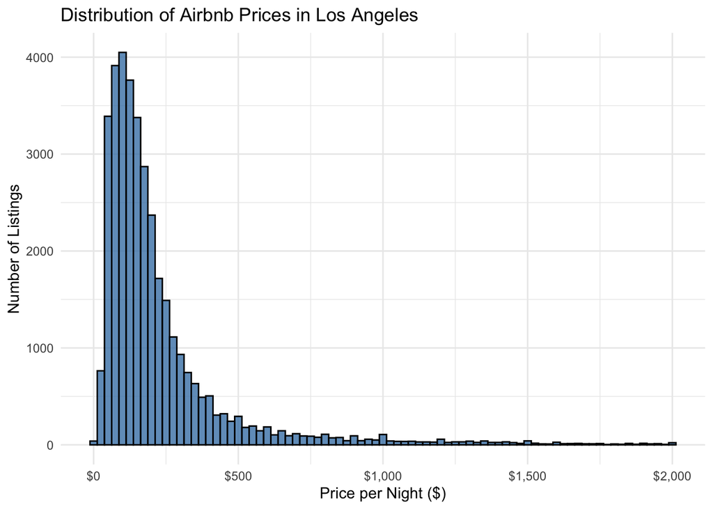

```r
# Basic histogram of price distribution
ggplot(listings, aes(x = price)) +
  geom_histogram(binwidth = 25, fill = "steelblue", color = "black", alpha = 0.8) +
  scale_x_continuous(labels = dollar_format()) +
  labs(title = "Distribution of Airbnb Prices in Los Angeles",
       x = "Price per Night ($)",
       y = "Number of Listings") +
  theme_minimal()
```

The price distribution is heavily right-skewed, with most listings clustered below $300 per night, indicating that budget and moderate-priced options make up the bulk of LA’s Airbnb market.

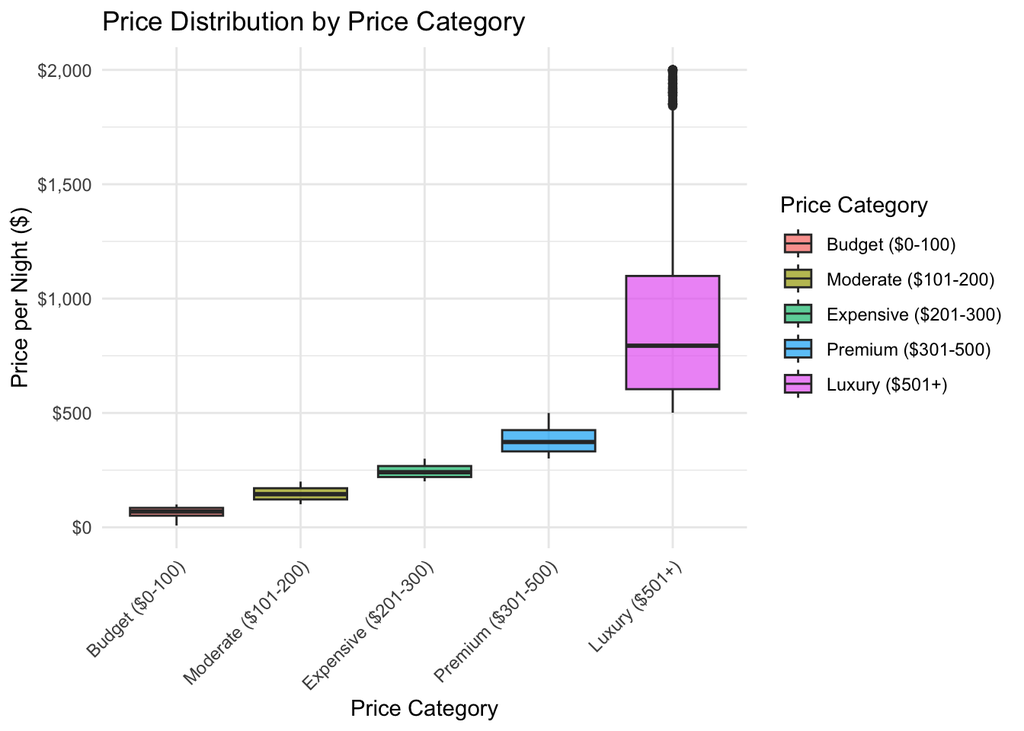

```r
# Boxplot of price distribution by price category
ggplot(listings, aes(x = price_category, y = price, fill = price_category)) +
  geom_boxplot(alpha = 0.7) +
  scale_y_continuous(labels = dollar_format()) +
  labs(title = "Price Distribution by Price Category",
       x = "Price Category",
       y = "Price per Night ($)",
       fill = "Price Category") +
  theme_minimal() +
  theme(axis.text.x = element_text(angle = 45, hjust = 1))
```

This boxplot reveals that while our price categories successfully group listings by price range, there is still considerable price variation within each category, particularly within the Luxury segment.

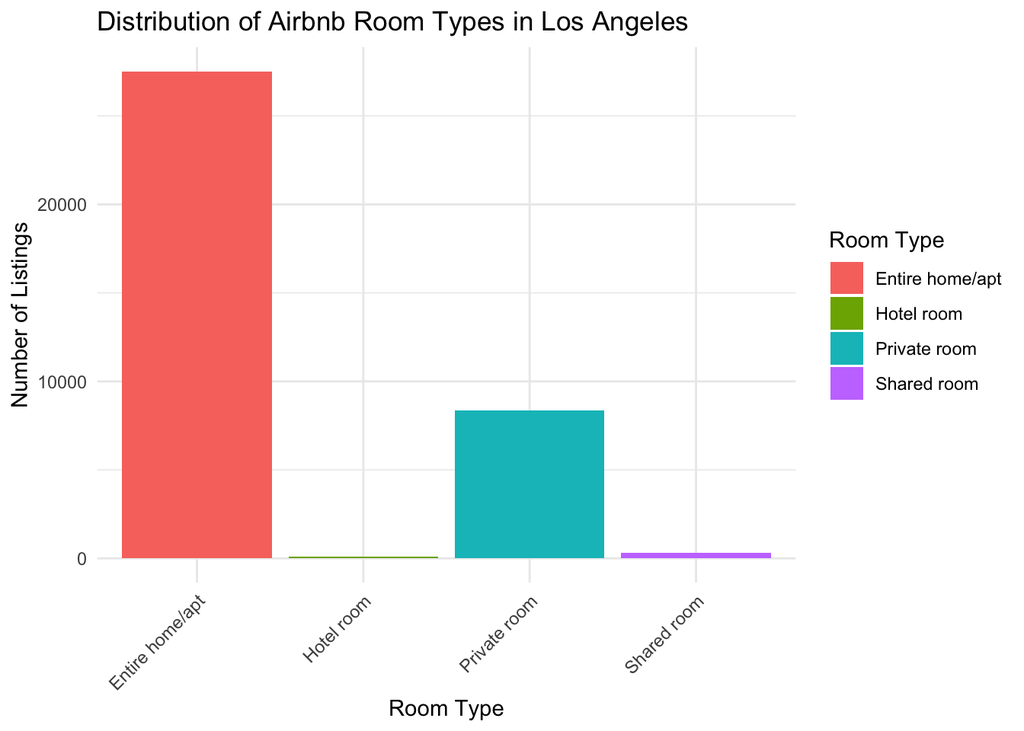

```r
# Bar chart of room types
ggplot(listings, aes(x = room_type, fill = room_type)) +
  geom_bar() +
  labs(title = "Distribution of Airbnb Room Types in Los Angeles",
       x = "Room Type",
       y = "Number of Listings",
       fill = "Room Type") +
  theme_minimal() +
  theme(axis.text.x = element_text(angle = 45, hjust = 1))
```

Entire homes and apartments dominate the Los Angeles Airbnb market, comprising over 75% of all listings, while hotel rooms and shared rooms represent a very small fraction of available options.

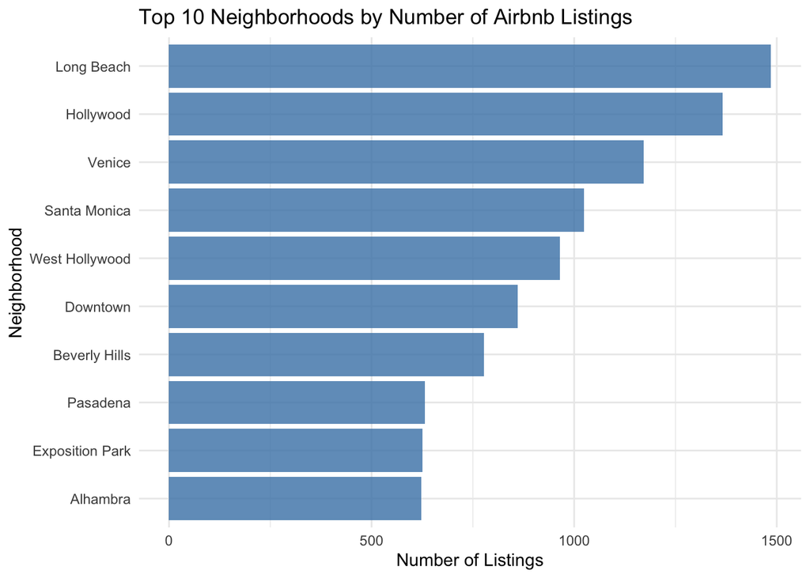

```r
# Top 10 neighborhoods by number of listings
top_neighborhoods <- listings |>
  count(neighbourhood) |>
  arrange(desc(n)) |>
  head(10)

ggplot(top_neighborhoods, aes(x = reorder(neighbourhood, n), y = n)) +
  geom_col(fill = "steelblue", alpha = 0.8) +
  coord_flip() +
  labs(title = "Top 10 Neighborhoods by Number of Airbnb Listings",
       x = "Neighborhood",
       y = "Number of Listings") +
  theme_minimal()
```

Long Beach has the highest concentration of Airbnb listings in Los Angeles, followed by Hollywood and Venice, showing that both coastal areas and central entertainment districts are popular for short-term rentals.

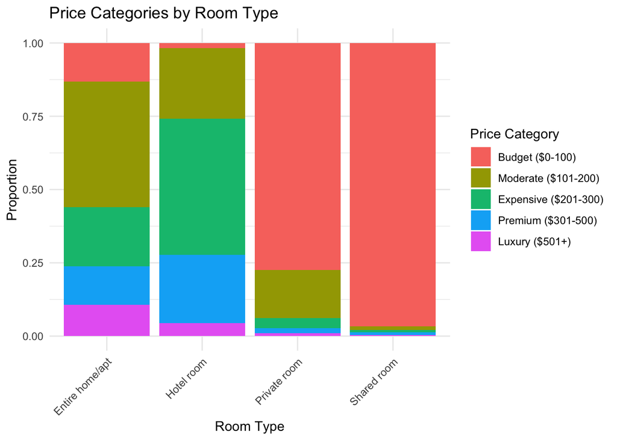

```r
# Cross-tabulation of room type and price category
ggplot(listings, aes(x = room_type, fill = price_category)) +
  geom_bar(position = "fill") +
  labs(title = "Price Categories by Room Type",
       x = "Room Type",
       y = "Proportion",
       fill = "Price Category") +
  theme_minimal() +
  theme(axis.text.x = element_text(angle = 45, hjust = 1))
```

**Preliminary Results**

```r
price_by_room <- listings |>
  group_by(room_type) |>
  summarise(
    `Number of Listings` = n(),
    `Percentage` = round(n() / nrow(listings) * 100, 1),
    `Average Price` = round(mean(price), 2),
    `Median Price` = median(price),
    `Price Range` = paste0("$", min(price), " - $", max(price))
  )

kable(price_by_room, caption = "Price Analysis by Room Type") |>
  kable_styling(bootstrap_options = c("striped", "hover"), full_width = FALSE)
```

Price Analysis by Room Type

| room_type | Number of Listings | Percentage | Average Price | Median Price | Price Range |
| --- | --- | --- | --- | --- | --- |
| Entire home/apt | 27513 | 75.8 | 270.94 | 184 | $14 - $2000 |
| Hotel room | 112 | 0.3 | 266.08 | 240 | $77 - $809 |
| Private room | 8364 | 23.1 | 92.89 | 68 | $8 - $1940 |
| Shared room | 297 | 0.8 | 38.26 | 27 | $8 - $713 |

Entire homes and apartments command the highest prices at $271 on average, nearly three times more expensive than private rooms at $93. While hotel rooms are similarly priced to entire homes, they represent less than 1% of all listings, making private rooms the most common budget-friendly option.

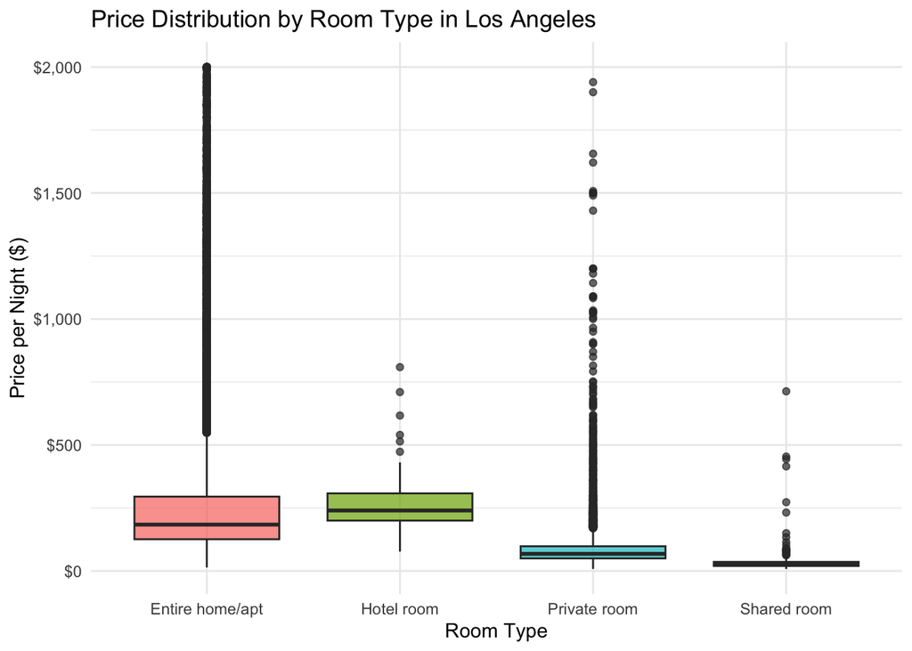

```r
ggplot(listings, aes(x = room_type, y = price, fill = room_type)) +
  geom_boxplot(alpha = 0.7) +
  scale_y_continuous(labels = dollar_format()) +
  labs(title = "Price Distribution by Room Type in Los Angeles",
       x = "Room Type",
       y = "Price per Night ($)",
       fill = "Room Type") +
  theme_minimal() +
  theme(legend.position = "none")
```

```r
top_neighborhoods <- listings |>
  group_by(neighbourhood) |>
  summarise(
    `Listings Count` = n(),
    `Average Price` = round(mean(price), 2),
    `Median Price` = round(median(price), 2)
  ) |>
  arrange(desc(`Average Price`)) |>
  head(10)

kable(top_neighborhoods, caption = "Top 10 Most Expensive Neighborhoods") |>
  kable_styling(bootstrap_options = c("striped", "hover"), full_width = FALSE)
```

Top 10 Most Expensive Neighborhoods

| neighbourhood | Listings Count | Average Price | Median Price |
| --- | --- | --- | --- |
| Beverly Crest | 148 | 859.78 | 744.5 |
| Unincorporated Catalina Island | 9 | 782.44 | 818.0 |
| Bel-Air | 38 | 777.97 | 772.0 |
| Malibu | 281 | 751.54 | 612.0 |
| Hollywood Hills West | 508 | 725.12 | 637.0 |
| Avalon | 238 | 613.37 | 543.5 |
| San Marino | 25 | 609.52 | 399.0 |
| Pacific Palisades | 91 | 533.04 | 365.0 |
| Unincorporated Santa Monica Mountains | 141 | 528.00 | 389.0 |
| Palos Verdes Estates | 15 | 490.27 | 297.0 |

Luxury neighborhoods like Beverly Crest, Bel-Air, and Malibu command premium prices exceeding $750 per night on average, with Beverly Crest listings costing nearly $860 on average. These affluent areas show high median prices as well, confirming consistently expensive listings rather than just a few extreme outliers.

```r
# Color by price category instead of exact price
category_pal <- colorFactor(palette = "viridis", domain = listings$price_category)

set.seed(123)
map_sample <- listings |> sample_n(2000)

leaflet(map_sample) |>
  addTiles() |>
  addCircleMarkers(
    lng = ~longitude, lat = ~latitude,
    radius = 3,
    color = ~category_pal(price_category),
    fillOpacity = 0.6,
    popup = ~paste(
      "Price: $", price, "<br>",
      "Category: ", price_category, "<br>",
      "Type: ", room_type, "<br>",
      "Neighborhood: ", neighbourhood
    )
  ) |>
  addLegend(
    "bottomright",
    pal = category_pal,
    values = ~price_category,
    title = "Price Category",
    opacity = 1
  ) |>
  setView(lng = -118.2437, lat = 34.0522, zoom = 10)
```

[interactive chart not shown]

The interactive map, displaying a random sample of 2,000 listings for clarity, reveals clear geographic patterns with luxury listings concentrated in coastal areas like Malibu and Santa Monica. Budget and moderate-priced options are more evenly distributed throughout the metropolitan area, while premium listings cluster in central neighborhoods like Hollywood and Beverly Hills, creating distinct price corridors across Los Angeles.

```r
availability_analysis <- listings |>
  mutate(
    availability_group = cut(availability_365,
                           breaks = c(0, 30, 90, 180, 365),
                           labels = c("Rarely (0-30 days)", "Occasional (31-90 days)",
                                    "Seasonal (91-180 days)", "Frequently (181-365 days)"))
  ) |>
  group_by(availability_group) |>
  summarise(
    `Number of Listings` = n(),
    `Percentage` = round(n() / nrow(listings) * 100, 1),
    `Average Price` = round(mean(price), 2),
    `Median Price` = round(median(price), 2)
  )

kable(availability_analysis, caption = "Price Variation by Annual Availability") |>
  kable_styling(bootstrap_options = c("striped", "hover"), full_width = FALSE)
```

Price Variation by Annual Availability

| availability_group | Number of Listings | Percentage | Average Price | Median Price |
| --- | --- | --- | --- | --- |
| Rarely (0-30 days) | 752 | 2.1 | 238.00 | 169 |
| Occasional (31-90 days) | 4310 | 11.9 | 207.41 | 145 |
| Seasonal (91-180 days) | 5302 | 14.6 | 224.15 | 157 |
| Frequently (181-365 days) | 25699 | 70.8 | 231.57 | 153 |
| NA | 223 | 0.6 | 268.76 | 170 |

Listings available year-round make up the majority of the market at 71%, while rarely-available properties command the highest average prices. Interestingly, seasonal listings are priced higher than occasional ones, suggesting hosts may adjust rates based on peak demand periods.

**Conclusion**

This analysis reveals that Airbnb listing prices, availability, and property types in Los Angeles vary dramatically across neighborhoods, creating distinct market segments. Luxury listings exceeding $750 per night concentrate in affluent areas like Beverly Crest, Bel-Air, and Malibu, while budget-friendly options under $100 are widely distributed throughout the metropolitan area. The market is dominated by entire homes and apartments (76% of listings), which command premium prices averaging $271, nearly three times higher than private rooms. Geographic patterns show clear price corridors, with coastal and hillside neighborhoods maintaining the highest price points. Most listings (71%) operate as frequently available rental businesses, though rarely-available properties command slightly higher prices, suggesting different hosting strategies across the market. This stratified ecosystem offers travelers diverse options ranging from luxury coastal retreats to affordable urban accommodations, reflecting Los Angeles’ varied neighborhood characteristics and appeal.